# Logistic regression

### Interpreting interaction

- interaction term is negative, what does this mean?
  - the effect of congruence is different in either level of tense
  - these effects are often more easily interpreted with a visualisation, e.g., using the `plot_model()` function from the `sjPlot` package (this effect is not significant, however)

Figure 2: Interaction plot of grammaticality and tense

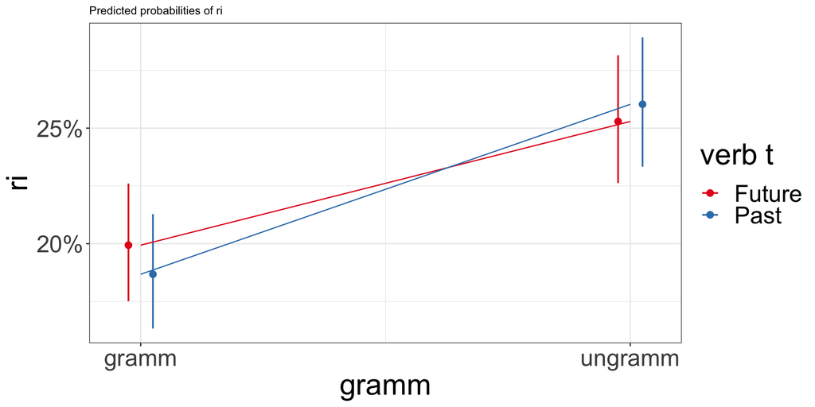

```r
sjPlot::plot_model(fit_tense_ri,
                   type = "eff",
                   terms = c("gramm", "verb_t")) +
  geom_line() +
  theme(text = element_text(size = 26))
```

### Extracting predicted values

- we can use the `predict()` function to extract the predicted values for each condition
- We could just simply print the predicted values (`predict(fit_tense_ri)`), append the predicted values to the data frame

```r
# make sure dataset is the same length as the model data
df_tense_v <-
  df_tense |>
  drop_na(ri)

# append model estimates
df_tense_v <-
  augment(fit_tense_ri, data = df_tense_v) |>
  distinct(verb_t, gramm, .keep_all = T) |>
  arrange(verb_t) |>
  select(verb_t, gramm, .fitted)
```

### Predicted values and slopes

- now if we look at the predicted log-odds values for the future and past tenses:

```r
df_tense_v |>
  summarise(
    mean_tense = mean(.fitted),
    .by = verb_t)
```

```
# A tibble: 2 × 2
  verb_t mean_tense
  <fct>       <dbl>
1 Future    -1.2367
2 Past      -1.2577
```

```r
df_tense_v |>
  summarise(
    mean_gramm = mean(.fitted),
    .by = gramm)
```

```
# A tibble: 2 × 2
  gramm   mean_gramm
  <fct>        <dbl>
1 gramm      -1.4307
2 ungramm    -1.0638
```

# Interpreting our coefficients

- what do our estimates reflect, though?
  - let’s remind ourselves of the rate of regressions in at the verb region:

```r
intercept <- tidy(fit_tense_ri)$estimate[1]
tense <- tidy(fit_tense_ri)$estimate[2]
gramm <- tidy(fit_tense_ri)$estimate[3]
interact <- tidy(fit_tense_ri)$estimate[4]
```

- let’s remind ourselves of our contrast coding, so we can plug these into our equation of a line

```r
contrasts(df_tense_v$verb_t)
```

```
       [,1]
Future  0.5
Past   -0.5
```

```r
contrasts(df_tense_v$gramm)
```

```
        [,1]
gramm   -0.5
ungramm  0.5
```

## Calculating our predictions

- what’s the probability of a regression in for the past (`tense` = -0.5) grammatical (`gramm` = -0.5) condition?

```r
plogis(intercept + tense*-.5 + gramm*-.5)
```

```
[1] 0.1913675
```

- and past ungrammatical (change `gramm` to +0.5)?

```r
plogis(intercept + tense*-.5 + gramm*.5)
```

```
[1] 0.2545957
```

- And for the future condition (`verb_t` = 0.5) grammatical (`gramm` = -0.5)?

```r
plogis(intercept + tense*.5 + gramm*-.5)
```

```
[1] 0.1946325
```

- and future ungrammatical (gramm = +0.5)?

```r
plogis(intercept + tense*.5 + gramm*.5)
```

```
[1] 0.2585946
```

$$\begin{equation}
y_i = b_0 + b_1x_i + b_2x_1 + ... + e \label{eq-line}
\end{equation}$$

## Math with factors

- so, even when our dependent *and* independent variables are categorical, we can include them in our equation of a line (equation $\ref{eq-line}$)
- we do this by assigning them numerical values
  - a probability/log odd/odds for a binomial dependent variable
  - and contrast coding for categorical predictors

# Reporting

Sonderegger (2023) (Section 6.9) makes a few important points regarding coefficients:

> Reporting a logistic regression model in a write-up is generally similar to reporting a linear regression model: the guidelines and rationale in section 4.6 for reporting individual coefficients and the whole model hold, with some adjustments.

> For each regression coefficient you report at a minimum the coefficient estimate, its SE, the test statistic value…and corresponding p-value.

> As for linear regression, it is useful to also give visualizations, CIs, and basic descriptive statistics, but what is appropriate will depend on context and space.

> Model prediction plots are especially important for interpreting logistic regressions, as discussed in section 6.7.3.

## Producing table summaries with `papaja`

```r
library(papaja)

fit_tense_ri |>
  apa_print() |>
  apa_table(label = "tbl-glm-summary",
            caption = "Model summary for regressions in at the verb region. Estimates are given in log odds.")
```

(#tab:unnamed-chunk-36) Model summary for regressions in at the verb region. Estimates are given in log odds.

| Predictor | $b$ | 95% CI | $z$ | $p$ |
| --- | --- | --- | --- | --- |
| Intercept | -1.25 | [-1.32, -1.17] | -31.81 | < .001 |
| Verb t1 | 0.02 | [-0.13, 0.17] | 0.27 | .789 |
| Gramm1 | 0.37 | [0.21, 0.52] | 4.68 | < .001 |
| Verb t1 $\times$ Gramm1 | -0.12 | [-0.43, 0.19] | -0.76 | .445 |

## Producing table summaries with `broom::tidy()`

```r
tidy(fit_tense_ri, conf.int = TRUE) |>
  mutate(prob = plogis(estimate)) |>
  relocate(prob, .after = std.error) |>
  apa_table(label = "tbl-glm-summary-tidy",
            caption = "Same table with `tidy()`")
```

(#tab:unnamed-chunk-37) Same table with `tidy()`

| term | estimate | std.error | prob | statistic | p.value | conf.low | conf.high |
| --- | --- | --- | --- | --- | --- | --- | --- |
| (Intercept) | -1.25 | 0.04 | 0.22 | -31.81 | 0.00 | -1.32 | -1.17 |
| verb_t1 | 0.02 | 0.08 | 0.51 | 0.27 | 0.79 | -0.13 | 0.17 |
| gramm1 | 0.37 | 0.08 | 0.59 | 4.68 | 0.00 | 0.21 | 0.52 |
| verb_t1:gramm1 | -0.12 | 0.16 | 0.47 | -0.76 | 0.45 | -0.43 | 0.19 |

# Learning Objectives

Today we learned…

- how to model binomial data with logistic regression
- how to interpret log-odds and odds ratio
- how to report a logistic regression model

# Important terms

[output not shown]

# Task

## Regressions in at the adverb region

Using the same dataset, run a logistic model exploring regressions in (`ri`) at the adverb region (`roi = "2"`). Before you run the model, do you have any predictions? Try plotting the regressions in for this region first, and generate some summary tables to get an idea of the distributions of regressions in across conditions.

## Dutch verb regularity

Load in the `regularity` data from the `languageR` package.

```r
df_reg <-
  regularity |>
  clean_names()
```

> Regular and irregular Dutch verbs and selected lexical and distributional properties.

Our relevant variables will be:

- `written_frequency`: a numeric vector of logarithmically transformed frequencies in written Dutch (as available in the CELEX lexical database).
- `regularity`: a factor with levels irregular (1) and regular (0).
- `verb`: a factor with the verbs as levels.

```r
names(df_reg)
```

```
 [1] "verb"                  "written_frequency"     "family_size"
 [4] "length_in_letters"     "verbal_synsets"        "mean_bigram_frequency"
 [7] "ncount_stem"           "regularity"            "inflectional_entropy"
[10] "auxiliary"             "valency"               "n_vratio"
[13] "written_spoken_ratio"
```

```r
df_reg |>
  mutate(reg_n = ifelse(regularity == "regular",1,0))
```

[output not shown]

[output cut: 2088 more lines]

1. Fit a logistic regression model to the data which predicts verb regularity by written frequency. Consider: What type of predictor variable do you have, and what steps should you take before fitting your model?
2. Print the model coefficients, e.g., using `tidy()`.
3. Interpret the coefficients, either in log-odds or probabilities. Report your findings.

# Literaturverzeichnis

Biondo, N., Soilemezidi, M., & Mancini, S. (2022). Yesterday is history, tomorrow is a mystery: An eye-tracking investigation of the processing of past and future time reference during sentence reading. *Journal of Experimental Psychology: Learning, Memory, and Cognition*, *48*(7), 1001–1018. https://doi.org/10.1037/xlm0001053

Sonderegger, M. (2023). *Regression Modeling for Linguistic Data*.

Winter, B. (2019). Statistics for Linguists: An Introduction Using R. In *Statistics for Linguists: An Introduction Using R*. Routledge. https://doi.org/10.4324/9781315165547